# Spatial Statistics Use Cases: Nigerian Wards as a Worked Example

**Advanced Spatial Statistics · Class Notebook · Data Science Nigeria**

All problems in this notebook are well defined in stages:

1. **The problem**: a real decision someone has to make.
2. **The hypothesis**: what we expect, stated so the data can prove us wrong.
3. **The usual approach**: how a standard (aspatial) statistics or ML workflow would answer it.
4. **The spatial statistics approach**: the method that respects geography, and why.
5. **Code → results → interpretation**: we run it and read what the numbers actually say.

### Contents

- Setup: data, neighbours and map helpers
1. Poverty clustering: is purchasing power randomly spread, or clustered?
2. Poverty and religion: do wealthier areas sit next to particular faith institutions?
3. Religious sorting and diversity: where do churches and mosques mix?
4. Healthcare deserts: where should mobile clinics go first?
5. Retail expansion: where is purchasing power high but market supply low?
6. Water inequality: how unequal is water infrastructure, and where are the water deserts?
7. School provision, and honest $p$-values: what explains school counts?
8. Market spillovers: do markets attract markets next door?
9. Security coverage: do wards without a police station cluster?
10. One slope or many? (GWR): does purchasing power relate to schooling the same way everywhere?
11. Malaria and poverty: where should malaria campaigns go, and is poverty the driver?

## Setup: data, neighbours and map helpers

```python
import warnings
warnings.filterwarnings("ignore")

import numpy as np
import pandas as pd
import geopandas as gpd
import matplotlib.pyplot as plt
import matplotlib.patches as mpatches
import libpysal
import esda
import spreg

np.random.seed(42)
plt.rcParams.update({"figure.dpi": 110, "font.size": 10, "axes.titleweight": "bold"})

DSN_GREEN, DSN_RED = "#00a859", "#ed3237"
LISA_COLOURS = {1: "#e3002b", 2: "#92dff3", 3: "#0571b0", 4: "#f98400", 0: "#eeeeee"}
# Thin, semi-transparent boundaries so ward outlines never hide the cluster colours
EDGE = (1, 1, 1, 0.35)
LISA_LABELS = {1: "High-High", 2: "Low-High", 3: "Low-Low", 4: "High-Low", 0: "Not significant"}

wards = gpd.read_parquet("../data/processed/nigeria_wards_master.parquet")
wards = wards[wards.rwi_mean.notna() & wards.pop_2025_sum.notna()].reset_index(drop=True)
wards = wards.rename(columns={"rwi_mean": "purchasing_power"})
wards["geometry_plot"] = wards.geometry.simplify(0.003)
print(f"{len(wards):,} wards across {wards.statename.nunique()} states")
```

```
8,874 wards across 37 states
```

```python
# Queen contiguity: two wards are neighbours if they share a border or a corner.
w_queen = libpysal.weights.Queen.from_dataframe(wards, use_index=False, silence_warnings=True)
# A few wards touch no other ward (islands); link each one to its nearest ward.
w_knn1 = libpysal.weights.KNN.from_dataframe(wards.set_geometry(wards.centroid), k=1)
w = libpysal.weights.util.attach_islands(w_queen, w_knn1)
w.transform = "r"   # row-standardise: neighbour values become an average
print(f"Islands fixed: {len(w_queen.islands)} | mean neighbours per ward: {w.mean_neighbors:.1f}")
```

```
Islands fixed: 9 | mean neighbours per ward: 5.9
```

```python
def base_map(ax, title):
    ax.set_title(title, loc="left")
    ax.set_axis_off()


def choropleth(column, title, cmap="RdYlGn", ax=None, legend=True, **kw):
    ax = ax or plt.subplots(figsize=(7, 6))[1]
    wards.set_geometry("geometry_plot").plot(column=column, cmap=cmap, ax=ax, legend=legend,
                                             linewidth=0.2, edgecolor=EDGE, **kw)
    base_map(ax, title)
    return ax


def lisa_map(lisa, title, alpha=0.05, ax=None, labels=None):
    labels = labels or LISA_LABELS
    ax = ax or plt.subplots(figsize=(7, 6))[1]
    cls = np.where(lisa.p_sim < alpha, lisa.q, 0)
    colours = [LISA_COLOURS[c] for c in cls]
    wards.set_geometry("geometry_plot").plot(color=colours, ax=ax, linewidth=0.2, edgecolor=EDGE)
    counts = pd.Series(cls).value_counts()
    handles = [mpatches.Patch(color=LISA_COLOURS[k], label=f"{labels[k]} ({counts.get(k, 0):,})")
               for k in (1, 3, 4, 2, 0)]
    ax.legend(handles=handles, loc="upper left", bbox_to_anchor=(1.0, 1.0), fontsize=8, frameon=False)
    base_map(ax, title)
    return ax


def lisa_summary(lisa, alpha=0.05, labels=None):
    labels = labels or LISA_LABELS
    cls = np.where(lisa.p_sim < alpha, lisa.q, 0)
    return pd.Series(cls).map(labels).value_counts().rename("wards").to_frame()
```

## Use Case 1: Poverty clustering

**The problem.** A development agency wants to target a cash-transfer programme. Should it pick the poorest *states*, or is poverty organised in pockets that cross state lines?

**Hypothesis.**

- $H_0$: purchasing power is spread randomly across wards (no spatial pattern).
- $H_1$: poor wards sit next to poor wards and rich next to rich (positive spatial autocorrelation).

**The usual approach.** Rank states by their average purchasing power and look at the histogram.

```
Poorest states (mean purchasing power):
statename
Kebbi     -0.24
Jigawa    -0.24
Bauchi    -0.24
Benue     -0.23
Zamfara   -0.23

Richest states:
statename
Ogun       0.08
Abia       0.26
Anambra    0.32
Imo        0.34
Lagos      0.81
```

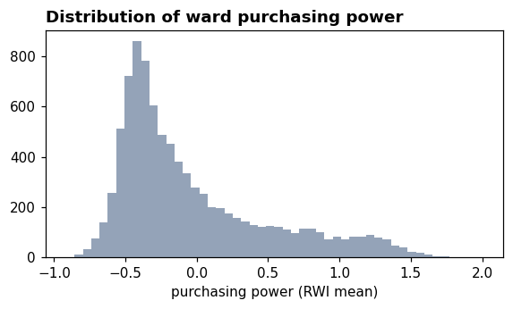

```python
state_avg = wards.groupby("statename").purchasing_power.mean().sort_values()
print("Poorest states (mean purchasing power):"); print(state_avg.head(5).round(2).to_string())
print("\nRichest states:"); print(state_avg.tail(5).round(2).to_string())

fig, ax = plt.subplots(figsize=(6, 3))
ax.hist(wards.purchasing_power, bins=50, color="#94a3b8")
ax.set_title("Distribution of ward purchasing power", loc="left"); ax.set_xlabel("purchasing power (RWI mean)")
plt.show()
```

**What the usual approach tells us.** The poorest states (Kebbi, Jigawa, Bauchi, Benue, Zamfara) all average about $-0.24$, while Lagos stands out at $0.81$. The histogram is skewed: most wards sit slightly below zero with a long tail of wealthier wards.

**What it cannot tell us.** Whether poor wards are next to each other or scattered. A state average of $-0.24$ could hide a wealthy town surrounded by very poor villages. If we shuffled the wards randomly across the map, every number above would stay exactly the same.

**The spatial statistics approach.** Global Moran's $I$ tests $H_0$ for the whole map; Anselin's Local Moran ($I_i$, LISA) then shows *where* the clusters and outliers are. Significance comes from 999 random permutations of the map.

```
Global Moran's I = 0.367  (expected under randomness -0.0001)
z = 56.8, pseudo p = 0.001
```

```
                 wards
Not significant   6963
Low-Low            773
High-High          763
High-Low           197
Low-High           178
```

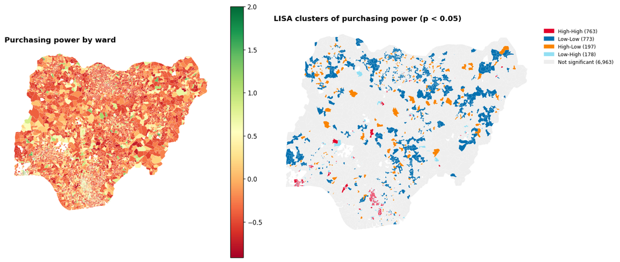

```python
moran_pp = esda.Moran(wards.purchasing_power.values, w, permutations=999)
print(f"Global Moran's I = {moran_pp.I:.3f}  (expected under randomness {moran_pp.EI:.4f})")
print(f"z = {moran_pp.z_sim:.1f}, pseudo p = {moran_pp.p_sim:.3f}")

lisa_pp = esda.Moran_Local(wards.purchasing_power.values, w, permutations=999, seed=42)
print(lisa_summary(lisa_pp).to_string())

fig, axes = plt.subplots(1, 2, figsize=(14, 6))
choropleth("purchasing_power", "Purchasing power by ward", ax=axes[0])
lisa_map(lisa_pp, "LISA clusters of purchasing power (p < 0.05)", ax=axes[1])
plt.tight_layout(); plt.show()
```

**Interpretation.**

- **Global Moran's $I = 0.367$** against an expectation of about 0 under randomness, with $z = 56.8$ and pseudo $p = 0.001$ (the smallest possible with 999 permutations). We **reject $H_0$**: purchasing power is strongly clustered.
- **LISA** finds **763 High-High** wards (wealth clusters) and **773 Low-Low** wards (poverty clusters). These are neighbourhoods, not states, and many cross state lines.
- **197 High-Low** wards are relatively wealthy wards surrounded by poorer ones (local economic anchors), and **178 Low-High** wards are poor pockets inside wealthier areas, the households that state averages hide.

**Decision.** Target the cash-transfer programme at the Low-Low clusters (contiguous areas one delivery network can serve) and add the Low-High pockets as a separate list. Do not allocate by state rank alone.

## Use Case 2: Poverty and religion

**The problem.** Civil-society groups often partner with faith institutions to reach poor households. Do areas with more churches or more mosques differ in purchasing power, and is that relationship *geographic*?

We measure each ward's **church share** = churches / (churches + mosques) among registered faith institutions. This describes institutions on the map, not the beliefs of individual residents.

**Hypothesis.**

- $H_0$: a ward's purchasing power is unrelated to the faith-institution mix around it.
- $H_1$: purchasing power and the surrounding church share are spatially associated.

**The usual approach.** A Pearson correlation between the two columns.

```python
faith = wards.churches_count + wards.mosques_count
wards["church_share"] = np.where(faith > 0, wards.churches_count / faith, np.nan)
has_faith = wards.church_share.notna()
r = np.corrcoef(wards.purchasing_power[has_faith], wards.church_share[has_faith])[0, 1]
print(f"Wards with at least one registered church or mosque: {has_faith.sum():,}")
print(f"Pearson r (purchasing power vs church share): {r:.3f}  ->  r^2 = {r**2:.3f}")
```

```
Wards with at least one registered church or mosque: 6,602
Pearson r (purchasing power vs church share): 0.169  ->  r^2 = 0.028
```

**What the usual approach tells us.** $r = 0.169$, so $r^2 = 0.028$: church share "explains" under 3% of the variation in purchasing power. A standard analysis would stop here and call the relationship negligible.

**What it cannot tell us.** Whether the relationship is concentrated in particular regions. A weak national correlation can be an average of strong local relationships in some places and none in others.

**The spatial statistics approach.** The **bivariate Moran's $I$** correlates purchasing power *in a ward* with the church share *in its neighbours*. The **bivariate LISA** maps where that relationship is locally significant. Wards with no faith institution take the national mean share so they neither add nor remove signal.

```
Bivariate Moran's I = 0.143, pseudo p = 0.001
```

```
                                      wards
Not significant                        3929
Low power, low church share nearby     1747
Low power, high church share nearby    1566
High power, high church share nearby   1096
High power, low church share nearby     536
```

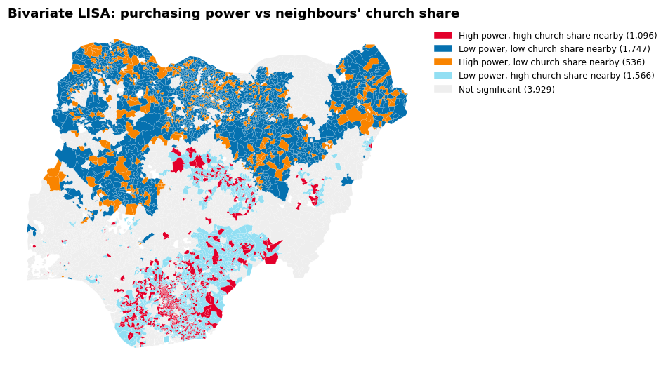

```python
share_filled = wards.church_share.fillna(wards.church_share.mean()).values
bv = esda.Moran_BV(wards.purchasing_power.values, share_filled, w, permutations=999)
print(f"Bivariate Moran's I = {bv.I:.3f}, pseudo p = {bv.p_sim:.3f}")

bv_lisa = esda.Moran_Local_BV(wards.purchasing_power.values, share_filled, w, permutations=999, seed=42)
bv_labels = {1: "High power, high church share nearby", 2: "Low power, high church share nearby",
             3: "Low power, low church share nearby", 4: "High power, low church share nearby",
             0: "Not significant"}
print(lisa_summary(bv_lisa, labels=bv_labels).to_string())
lisa_map(bv_lisa, "Bivariate LISA: purchasing power vs neighbours' church share", labels=bv_labels)
plt.show()
```

**Interpretation.**

- **Bivariate Moran's $I = 0.143$, $p = 0.001$**: wards with higher purchasing power tend to be surrounded by wards with a higher church share. The association is weak but it is real, and it is *spatial*.
- Most significant wards are **Low power, low church share nearby (1,747)** and **Low power, high church share nearby (1,566)**. Low purchasing power is common in both mosque-dominated and church-dominated regions, so faith mix is not the driver of poverty.
- **1,096 High-High** wards sit mostly in the wealthier south, which is also where churches dominate; this overlap drives the positive global value.

**Caution.** This is an association between two geographic patterns (both follow the north-south divide), not evidence that faith institutions cause wealth or poverty. For programme design, the useful output is the map: it shows which kind of faith partner is present in each poor cluster.

## Use Case 3: Religious sorting and diversity

**The problem.** A peace-building NGO wants to locate *transition zones* where churches and mosques sit side by side (places to host inter-faith dialogue), and zones that are strongly one-sided.

**Hypothesis.**

- $H_0$: the church/mosque mix is randomly arranged across wards.
- $H_1$: faith institutions are geographically sorted, with a band of mixed wards between.

**The usual approach.** A table of shares by state.

```python
by_state = (wards.groupby("statename")[["churches_count", "mosques_count"]].sum()
            .assign(church_share=lambda d: d.churches_count / (d.churches_count + d.mosques_count))
            .sort_values("church_share"))
print(by_state.church_share.round(2).describe().to_string())
print("\nMost mosque-dominated states:", ", ".join(by_state.index[:4]))
print("Most church-dominated states:", ", ".join(by_state.index[-4:]))
```

```
count    36.00000
mean      0.59750
std       0.37737
min       0.00000
25%       0.12750
50%       0.70500
75%       0.99000
max       1.00000

Most mosque-dominated states: Sokoto, Zamfara, Jigawa, Kano
Most church-dominated states: Anambra, Ebonyi, Akwa Ibom, Osun
```

**What the usual approach tells us.** State church shares range from 0 to 1 with a median of about 0.71. Sokoto, Zamfara, Jigawa and Kano are almost entirely mosque-dominated; Anambra, Ebonyi, Akwa Ibom and Osun are almost entirely church-dominated.

**What it cannot tell us.** Where, *within* states, the two faiths meet. The mixing happens along a band that cuts across state boundaries.

**The spatial statistics approach.** First, Moran's $I$ on church share measures how strongly faiths are sorted in space. Second, we compute **Shannon diversity** for each ward, $H = -\sum_k p_k \ln p_k$ (0 = one faith only, $\ln 2 \approx 0.69$ = perfectly mixed), and run **Getis-Ord $G_i^*$** to find statistically significant clusters of high diversity (mixing zones) and low diversity.

```
Moran's I (church share) = 0.731, pseudo p = 0.001
```

```
diversity_cluster
Single-faith zone (cold)    5138
Not significant             2186
Mixing zone (hot)           1550

States with most mixing-zone wards:
statename
Niger       171
Lagos       167
Oyo         139
Nasarawa    125
Kaduna      106
Ondo         90
```

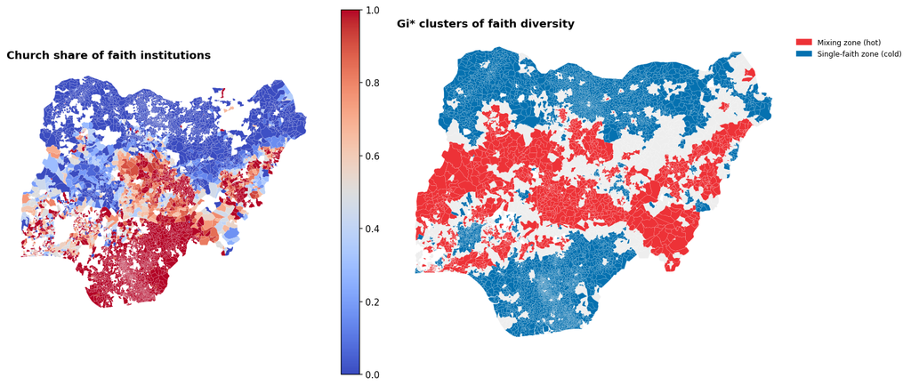

```python
moran_share = esda.Moran(share_filled, w, permutations=999)
print(f"Moran's I (church share) = {moran_share.I:.3f}, pseudo p = {moran_share.p_sim:.3f}")

p_c = (wards.churches_count / faith).where(faith > 0, 0)
p_m = (wards.mosques_count / faith).where(faith > 0, 0)
entropy = -(p_c * np.log(p_c.where(p_c > 0, 1)) + p_m * np.log(p_m.where(p_m > 0, 1)))
wards["faith_diversity"] = entropy.where(faith > 0, 0)

gi_div = esda.G_Local(wards.faith_diversity.values, w, star=True, permutations=999, seed=42)
wards["diversity_cluster"] = np.select(
    [(gi_div.Zs > 0) & (gi_div.p_sim < 0.05), (gi_div.Zs < 0) & (gi_div.p_sim < 0.05)],
    ["Mixing zone (hot)", "Single-faith zone (cold)"], "Not significant")
print(wards.diversity_cluster.value_counts().to_string())
print("\nStates with most mixing-zone wards:")
print(wards.loc[wards.diversity_cluster == "Mixing zone (hot)", "statename"].value_counts().head(6).to_string())

colours = wards.diversity_cluster.map({"Mixing zone (hot)": DSN_RED, "Single-faith zone (cold)": "#0571b0",
                                      "Not significant": "#eeeeee"})
fig, axes = plt.subplots(1, 2, figsize=(14, 6))
choropleth("church_share", "Church share of faith institutions", cmap="coolwarm", ax=axes[0])
wards.set_geometry("geometry_plot").plot(color=colours, ax=axes[1], linewidth=0.2, edgecolor=EDGE)
axes[1].legend(handles=[mpatches.Patch(color=DSN_RED, label="Mixing zone (hot)"),
                        mpatches.Patch(color="#0571b0", label="Single-faith zone (cold)")],
               loc="upper left", bbox_to_anchor=(1.0, 1.0), fontsize=8, frameon=False)
base_map(axes[1], "Gi* clusters of faith diversity")
plt.tight_layout(); plt.show()
```

**Interpretation.**

- **Moran's $I = 0.731$, $p = 0.001$** for church share: one of the strongest spatial patterns in the whole dataset. Faith institutions are highly sorted in space.
- **Getis-Ord $G_i^*$ on Shannon diversity** finds **1,550 mixing-zone wards** (statistically significant clusters of high diversity), led by **Niger, Lagos, Oyo, Nasarawa and Kaduna**: the Middle Belt and the south-west.
- **5,138 wards** fall in single-faith zones.

**Decision.** The mixing-zone clusters are where inter-faith dialogue programmes and early-warning systems for communal tension add the most value, and they span state borders, so programmes should be designed across states.

## Use Case 4: Healthcare deserts

**The problem.** A state health ministry has a limited fleet of mobile clinics. Which areas should they serve first?

**Hypothesis.**

- $H_0$: wards with large populations and no registered health facility are scattered at random.
- $H_1$: these "healthcare deserts" form contiguous clusters, where a single mobile route can serve many wards.

**The usual approach.** List every ward with more than 17,000 residents and zero registered facilities, sorted by population.

```python
wards["desert"] = (wards.pop_2025_sum > 17_000) & (wards.health_facilities_count == 0)
deserts = wards[wards.desert].sort_values("pop_2025_sum", ascending=False)
print(f"Healthcare deserts: {len(deserts):,} wards, {deserts.pop_2025_sum.sum()/1e6:.1f} million residents")
print(deserts[["wardname", "lganame", "statename", "pop_2025_sum"]].head(8).round(0).to_string(index=False))
```

```
Healthcare deserts: 1,675 wards, 69.8 million residents
  wardname         lganame statename  pop_2025_sum
   Mbaapen          Buruku     Benue      612680.0
 Aheward 9     Ahoada East    Rivers      339846.0
    Umudim         Ikeduru       Imo      337763.0
    Umuihi    Ihitte/Uboma       Imo      319497.0
   Auchi 3     Etsako West       Edo      313032.0
Sabon Gida  Langtang South   Plateau      261189.0
    Siluko Ovia South-West       Edo      260830.0
   Kwesati            Ussa    Taraba      260712.0
```

**What the usual approach tells us.** **1,675 wards** with more than 17,000 residents have no registered health facility, holding about **69.8 million** people. The list is headed by very large wards such as Mbaapen (Benue), Aheward 9 (Rivers) and Umudim (Imo).

**What it cannot tell us.** Which deserts are next to each other. A mobile clinic that parks in one ward can serve its neighbours too, so a flat list wastes that advantage.

**Data caveat.** "No registered facility" means none in the GRID3 registry. Some dense urban wards will have unregistered private clinics, so treat the list as "where to verify first".

**The spatial statistics approach.** Instead of a flat list, run **Getis-Ord $G_i^*$** on *unserved population* (population in wards with no registered facility, 0 elsewhere). A hot spot is a neighbourhood where unserved people are concentrated beyond chance: exactly where one mobile route reaches the most people.

```
Hot-spot wards: 957
Deserts inside hot spots: 537 of 1,675

States with the most hot-spot wards:
statename
Lagos          160
Anambra        109
Rivers          94
Imo             84
Cross River     73
Akwa Ibom       67
```

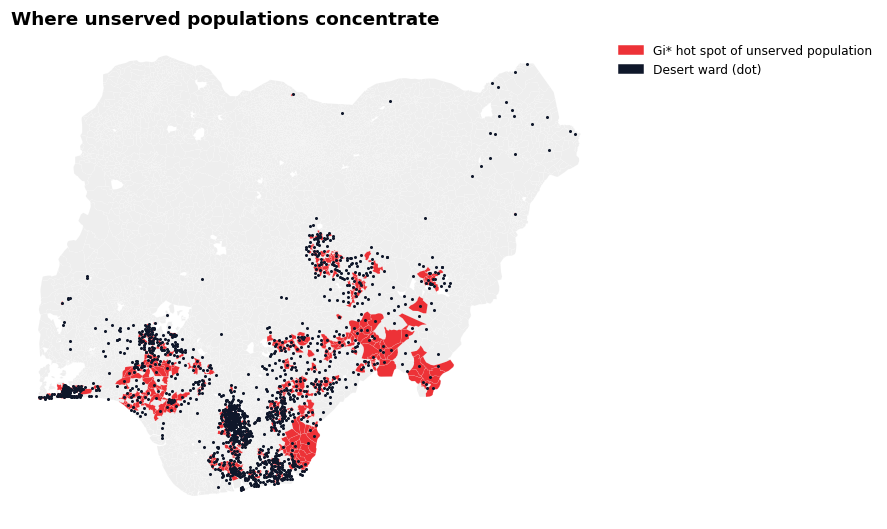

```python
unserved = np.where(wards.health_facilities_count == 0, wards.pop_2025_sum, 0.0)
gi_unserved = esda.G_Local(unserved, w, star=True, permutations=999, seed=42)
wards["unserved_hotspot"] = (gi_unserved.Zs > 0) & (gi_unserved.p_sim < 0.05)

print(f"Hot-spot wards: {wards.unserved_hotspot.sum():,}")
print(f"Deserts inside hot spots: {(wards.desert & wards.unserved_hotspot).sum():,} of {wards.desert.sum():,}")
print("\nStates with the most hot-spot wards:")
print(wards[wards.unserved_hotspot].statename.value_counts().head(6).to_string())

fig, ax = plt.subplots(figsize=(7, 6))
wards.set_geometry("geometry_plot").plot(color="#eeeeee", ax=ax, linewidth=0.2, edgecolor=EDGE)
wards[wards.unserved_hotspot].set_geometry("geometry_plot").plot(color=DSN_RED, ax=ax, linewidth=0.2, edgecolor=EDGE)
wards[wards.desert].set_geometry(wards[wards.desert].centroid).plot(ax=ax, color="#0f172a", markersize=1)
ax.legend(handles=[mpatches.Patch(color=DSN_RED, label="Gi* hot spot of unserved population"),
                   mpatches.Patch(color="#0f172a", label="Desert ward (dot)")], loc="upper left", bbox_to_anchor=(1.0, 1.0), fontsize=8, frameon=False)
base_map(ax, "Where unserved populations concentrate")
plt.show()
```

**Interpretation.**

- **957 wards** sit in statistically significant hot spots of unserved population; **537 of the 1,675 deserts** fall inside them. Those 537 are the priority: deserts surrounded by other deserts.
- The most hot-spot wards are in **Lagos, Anambra, Rivers, Imo and Cross River**. Because Lagos is well served in reality, its presence is a strong sign of **registry gaps** (private facilities not mapped) rather than a true desert.

**Decision.** Route mobile clinics through the hot-spot clusters outside the big cities first, and send a facility-mapping team to the urban hot spots to confirm whether the gap is real or a data gap.

## Use Case 5: Retail expansion

**The problem.** A supermarket chain wants to open new branches where customers have money to spend but markets are scarce *in the surrounding area* (not just in one ward).

**Hypothesis.**

- $H_0$: market density around a ward is unrelated to the ward's purchasing power.
- $H_1$: there are significant pockets where high purchasing power sits beside low market supply (under-served demand).

**The usual approach.** Correlate purchasing power with markets per 10,000 people.

```python
wards["markets_per_10k"] = wards.markets_count / wards.pop_2025_sum * 1e4
r5 = np.corrcoef(wards.purchasing_power, wards.markets_per_10k)[0, 1]
print(f"Pearson r (purchasing power vs markets per 10k people): {r5:.3f}")
```

```
Pearson r (purchasing power vs markets per 10k people): -0.026
```

**What the usual approach tells us.** $r = -0.026$: essentially **no relationship** between purchasing power and market density. A standard analysis would conclude that purchasing power is useless for choosing store locations.

**What it cannot tell us.** That "no relationship on average" can hide hundreds of specific places where high purchasing power meets low supply, and exactly those places are the business opportunity.

**The spatial statistics approach.** A **bivariate LISA** of purchasing power (in the ward) against markets per 10k (in the neighbours). The **High-Low** category (high purchasing power, low market supply around) is the expansion shortlist.

```
                                         wards
Not significant                           6979
Low power, few markets around              850
Low power, many markets around             431
High power, few markets around (target)    425
High power, many markets around            189

Top target states:
statename
Kogi      49
Oyo       41
Rivers    34
Kwara     28
Yobe      22
Sokoto    21
```

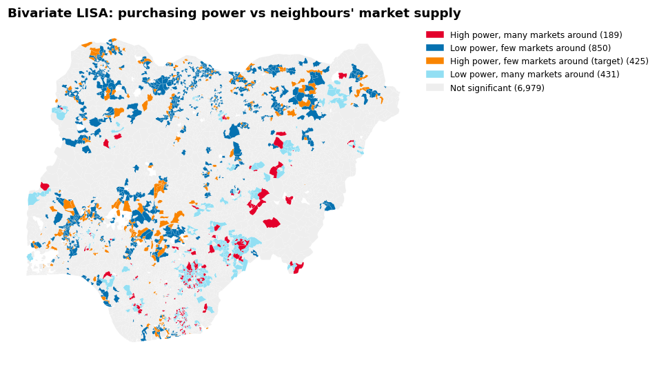

```python
retail = esda.Moran_Local_BV(wards.purchasing_power.values, wards.markets_per_10k.values, w,
                             permutations=999, seed=42)
retail_labels = {1: "High power, many markets around", 2: "Low power, many markets around",
                 3: "Low power, few markets around", 4: "High power, few markets around (target)",
                 0: "Not significant"}
print(lisa_summary(retail, labels=retail_labels).to_string())

targets = wards[(retail.q == 4) & (retail.p_sim < 0.05)]
print("\nTop target states:"); print(targets.statename.value_counts().head(6).to_string())
lisa_map(retail, "Bivariate LISA: purchasing power vs neighbours' market supply", labels=retail_labels)
plt.show()
```

**Interpretation.**

- The bivariate LISA flags **425 wards with high purchasing power and few markets around them**: the expansion shortlist that the correlation of $-0.03$ completely missed.
- They concentrate in **Kogi, Oyo, Rivers, Kwara, Yobe and Sokoto**.
- **189 wards** are already high power with many markets around (saturated, competitive), and **850** are low power with few markets (low demand).

**Decision.** Scout the 425 High-Low wards first, starting with the states where they cluster, and avoid the 189 saturated High-High wards.

## Use Case 6: Water inequality

**The problem.** A WASH programme needs to show donors how unequal water-point provision is, and where the largest *contiguous* water deserts are.

**Hypothesis.**

- $H_0$: water points per person are spread evenly and without spatial pattern.
- $H_1$: provision is highly unequal and the gaps cluster geographically.

**The usual approach.** A Gini coefficient and Lorenz curve of water points across wards.

```
Gini of water points across wards: 0.857
Wards with no registered water point: 65.8%
```

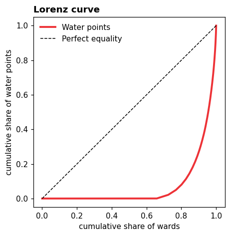

```python
def gini(values):
    x = np.sort(np.asarray(values, dtype=float)); n = len(x)
    return (2 * np.arange(1, n + 1) - n - 1).dot(x) / (n * x.sum())

wp = wards.water_points_count.values
print(f"Gini of water points across wards: {gini(wp):.3f}")
print(f"Wards with no registered water point: {(wp == 0).mean():.1%}")

x = np.sort(wp); lorenz = np.insert(np.cumsum(x) / x.sum(), 0, 0)
fig, ax = plt.subplots(figsize=(4.5, 4.5))
ax.plot(np.linspace(0, 1, len(lorenz)), lorenz, color=DSN_RED, lw=2.5, label="Water points")
ax.plot([0, 1], [0, 1], "k--", lw=1, label="Perfect equality")
ax.set_xlabel("cumulative share of wards"); ax.set_ylabel("cumulative share of water points")
ax.set_title("Lorenz curve", loc="left"); ax.legend(frameon=False); plt.show()
```

**What the usual approach tells us.** A **Gini of 0.857** is extreme inequality: **65.8% of wards have no registered water point** at all, and a small share of wards holds most of the infrastructure (the Lorenz curve hugs the bottom axis until the very end).

**What it cannot tell us.** Where the gaps are, and whether they form continuous regions a single programme could cover.

**The spatial statistics approach.** The Gini says *how unequal*, not *where*. Moran's $I$ and LISA on water points per 10,000 people (log-scaled) reveal **Low-Low clusters**: contiguous water deserts where a single borehole programme can cover many neighbouring wards.

```
Moran's I (water points per 10k, log) = 0.608, pseudo p = 0.001
```

```
                 wards
Not significant   6410
High-High         1408
Low-Low            759
Low-High           266
High-Low            31

People living in Low-Low water-desert clusters: 21.0 million
statename
Kano       90
Katsina    59
Borno      54
Jigawa     52
Sokoto     46
Bauchi     46
```

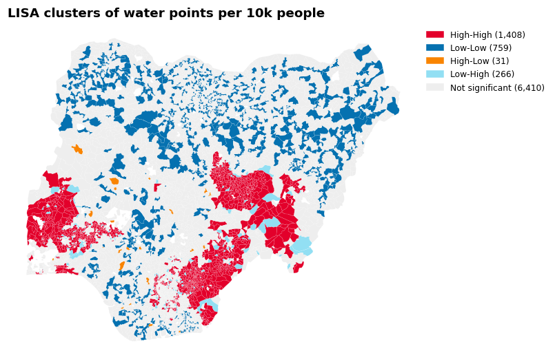

```python
wards["water_per_10k_log"] = np.log1p(wards.water_points_count / wards.pop_2025_sum * 1e4)
moran_w = esda.Moran(wards.water_per_10k_log.values, w, permutations=999)
print(f"Moran's I (water points per 10k, log) = {moran_w.I:.3f}, pseudo p = {moran_w.p_sim:.3f}")

lisa_w = esda.Moran_Local(wards.water_per_10k_log.values, w, permutations=999, seed=42)
print(lisa_summary(lisa_w).to_string())
water_deserts = wards[(lisa_w.q == 3) & (lisa_w.p_sim < 0.05)]
print(f"\nPeople living in Low-Low water-desert clusters: {water_deserts.pop_2025_sum.sum()/1e6:.1f} million")
print(water_deserts.statename.value_counts().head(6).to_string())
lisa_map(lisa_w, "LISA clusters of water points per 10k people"); plt.show()
```

**Interpretation.**

- **Moran's $I = 0.608$, $p = 0.001$**: water provision is strongly clustered, so both good and poor access come in regions.
- **759 Low-Low wards** form contiguous water deserts home to about **21.0 million people**, concentrated in **Kano, Katsina, Borno, Jigawa, Sokoto and Bauchi** (the north).
- **1,408 High-High wards** show where water points are densely clustered.

**Decision.** A borehole programme should be planned per Low-Low cluster rather than per ward, which lets drilling rigs and maintenance teams cover neighbouring wards in one deployment.

## Use Case 7: School provision, and honest $p$-values

**The problem.** The education ministry asks: does purchasing power predict how many schools a ward has, after accounting for population and area? They will use the $p$-values to justify funding rules.

**Hypothesis.**

- $H_0$: once population and area are controlled for, purchasing power has no effect on school counts.
- $H_1$: wealthier wards have more schools.

**The usual approach.** Ordinary Least Squares (OLS) on the log of school counts.

```python
y7 = np.log1p(wards.schools_count.values).reshape(-1, 1)
X7 = np.column_stack([np.log(wards.pop_2025_sum), wards.purchasing_power, np.log(wards.ward_area_sqkm)])
names7 = ["log_population", "purchasing_power", "log_area"]
ols7 = spreg.OLS(y7, X7, w=w, spat_diag=True, moran=True, name_y="log_schools", name_x=names7)
print(pd.DataFrame({"coef": ols7.betas.ravel(), "std_err": ols7.std_err, "p": [t[1] for t in ols7.t_stat]},
                   index=["constant"] + names7).round(4).to_string())
print(f"\nR^2 = {ols7.r2:.3f}")
```

```
                    coef  std_err    p
constant          0.7913   0.0796  0.0
log_population    0.0887   0.0081  0.0
purchasing_power  0.2790   0.0168  0.0
log_area          0.1673   0.0055  0.0

R^2 = 0.116
```

**What the usual approach tells us.** Every coefficient looks highly significant ($p \approx 0$). Purchasing power has a coefficient of **0.279**: wealthier wards have more schools, holding population and area constant. The model explains only **11.6%** of the variation ($R^2 = 0.116$).

**The worry.** Those $p$-values assume every ward is an independent observation. If neighbouring wards share unmeasured factors (state education budgets, history, terrain), the errors are correlated and the $p$-values are too optimistic.

**The spatial statistics approach.** OLS assumes the errors are independent. Test that with **Moran's $I$ on the residuals**, then use the **Lagrange Multiplier (LM) tests** to choose between a Spatial Lag and a Spatial Error model. If LM-error dominates, fit a **Spatial Error Model** (here the heteroskedasticity-robust GMM version).

```python
print(f"Residual Moran's I = {ols7.moran_res[0]:.3f} (z = {ols7.moran_res[1]:.1f})")
diag = pd.DataFrame({"statistic": [ols7.lm_lag[0], ols7.lm_error[0], ols7.rlm_lag[0], ols7.rlm_error[0]],
                     "p": [ols7.lm_lag[1], ols7.lm_error[1], ols7.rlm_lag[1], ols7.rlm_error[1]]},
                    index=["LM-lag", "LM-error", "Robust LM-lag", "Robust LM-error"])
print(diag.round(4).to_string())

sem7 = spreg.GM_Error_Het(y7, X7, w=w, name_y="log_schools", name_x=names7)
compare = pd.DataFrame({"OLS coef": ols7.betas.ravel()[:4], "SEM coef": sem7.betas.ravel()[:4],
                        "OLS std err": ols7.std_err[:4], "SEM std err": sem7.std_err[:4]},
                       index=["constant"] + names7)
print("\n", compare.round(4).to_string())
print(f"\nlambda (spatial error parameter) = {sem7.betas.ravel()[-1]:.3f}")
```

```
Residual Moran's I = 0.358 (z = 56.0)
                 statistic    p
LM-lag           2755.6972  0.0
LM-error         3131.7959  0.0
Robust LM-lag      22.5425  0.0
Robust LM-error   398.6413  0.0
GM_Error_Het

                   OLS coef  SEM coef  OLS std err  SEM std err
constant            0.7913    0.7299       0.0796       0.0734
log_population      0.0887    0.0534       0.0081       0.0069
purchasing_power    0.2790    0.1420       0.0168       0.0160
log_area            0.1673    0.2664       0.0055       0.0077

lambda (spatial error parameter) = 0.671
```

**Interpretation.**

- **Residual Moran's $I = 0.358$ ($z = 56$)**: the OLS errors are strongly clustered, so OLS independence fails and its standard errors cannot be trusted.
- **LM tests**: both LM-lag and LM-error are significant, so we read the robust versions. **Robust LM-error (398.6) is far larger than Robust LM-lag (22.5)**, which points to a **Spatial Error Model**: shared unmeasured regional factors, not schools "spreading" between wards.
- **SEM results**: $\lambda = 0.671$, a strong shared regional component. The purchasing power effect **halves from 0.279 to 0.142**, and the population effect drops from 0.089 to 0.053. OLS was attributing to wealth part of what is really regional context.

**Decision.** Wealth still matters (0.142 remains significant), but a funding rule based on the OLS figure would overstate its effect by about double.

## Use Case 8: Market spillovers

**The problem.** A state government plans to upgrade urban wards and wants to know how many extra markets that brings, *including* markets that appear in neighbouring wards.

**Hypothesis.**

- $H_0$: the number of markets in a ward depends only on the ward's own characteristics.
- $H_1$: markets attract markets next door (spatial contagion), so effects ripple outward.

**The usual approach.** OLS of log market counts on population, urban status and area.

```python
y8 = np.log1p(wards.markets_count.values).reshape(-1, 1)
X8 = np.column_stack([np.log(wards.pop_2025_sum), (wards.urban == "Yes").astype(float),
                      np.log(wards.ward_area_sqkm)])
names8 = ["log_population", "urban", "log_area"]
ols8 = spreg.OLS(y8, X8, w=w, spat_diag=True, name_y="log_markets", name_x=names8)
print(pd.DataFrame({"coef": ols8.betas.ravel(), "p": [t[1] for t in ols8.t_stat]},
                   index=["constant"] + names8).round(4).to_string())
print(f"\nR^2 = {ols8.r2:.3f} | Robust LM-lag = {ols8.rlm_lag[0]:.1f} | Robust LM-error = {ols8.rlm_error[0]:.1f}")
```

```
                  coef       p
constant        0.2650  0.0001
log_population  0.0047  0.4827
urban           0.2507  0.0000
log_area        0.0566  0.0000

R^2 = 0.017 | Robust LM-lag = 79.5 | Robust LM-error = 281.8
```

**What the usual approach tells us.** Urban wards have more markets (coefficient **0.251**, $p < 0.001$); population has no significant effect ($p = 0.48$). But $R^2 = 0.017$: OLS explains almost nothing, and both robust LM tests are significant (lag 79.5, error 281.8). There is spatial structure OLS is missing.

**The spatial statistics approach.** A **Spatial Lag Model (SAR)**, $y = \rho W y + X\beta + \varepsilon$, estimated by maximum likelihood. Because of the $\rho W y$ term, the raw $\beta$ is *not* the effect: we report **direct** (own ward), **indirect** (spillover to neighbours) and **total** impacts.

```python
from scipy.sparse import SparseEfficiencyWarning
warnings.simplefilter("ignore", SparseEfficiencyWarning)
sar8 = spreg.ML_Lag(y8, X8, w=w, method="LU", spat_impacts="simple", name_y="log_markets", name_x=names8)
print(f"rho = {float(sar8.rho):.3f} | spatial multiplier 1/(1-rho) = {1/(1-float(sar8.rho)):.2f}")
report = str(sar8.summary)
start = report.find("SPATIAL LAG MODEL IMPACTS")
print(report[start:report.find("=====", start)])
```

```
ML_Lag
rho = 0.594 | spatial multiplier 1/(1-rho) = 2.46
SPATIAL LAG MODEL IMPACTS
Impacts computed using the 'simple' method.
            Variable         Direct        Indirect          Total
      log_population         0.0091          0.0134          0.0225
               urban         0.2030          0.2971          0.5001
            log_area         0.0587          0.0859          0.1446
```

**Interpretation.**

- **$\rho = 0.594$**: a ward's number of markets is strongly tied to the number of markets in its neighbours. Markets attract markets.
- **Spatial multiplier $1/(1-\rho) = 2.46$**: any local change is amplified about 2.5 times once the ripple through neighbours is counted.
- **Impacts for urban status**: direct **0.203** in the ward itself, plus an indirect spillover of **0.297** into neighbouring wards, a total of **0.500**. **More than half of the total effect happens outside the upgraded ward.**

**Decision.** When evaluating an urban upgrade, count the market growth in surrounding wards too. Judging the programme by the upgraded ward alone would miss about 60% of its effect.

*Note: the robust LM-error was also large, so a Spatial Durbin Model would be a good next step; SAR is used here to show how to read impacts.*

## Use Case 9: Security coverage

**The problem.** The police service wants to know whether wards without a police station are scattered, or whether whole neighbourhoods of wards are uncovered (making response times worse).

**Hypothesis.**

- $H_0$: wards with no police station are arranged at random.
- $H_1$: uncovered wards cluster together ("security dark zones").

**The usual approach.** The share of wards with no registered police station.

```python
wards["no_police"] = (wards.police_stations_count == 0).astype(int)
print(f"Wards with no registered police station: {wards.no_police.mean():.1%}")
print(wards.groupby("urban").no_police.mean().rename("share without police").round(3).to_string())
```

```
Wards with no registered police station: 92.8%
urban
No     0.942
Yes    0.846
```

**What the usual approach tells us.** **92.8% of wards have no registered police station** (94.2% of rural wards, 84.6% of urban wards). Coverage is thin almost everywhere.

**The spatial statistics approach.** For a yes/no variable we use **Join Counts**: count neighbour pairs that are both "no police" (BB joins) and compare with random shuffles. Then **local join counts** find each ward whose entire neighbourhood is uncovered.

```
BB joins (no-police next to no-police): observed 22,557, expected under randomness 22,542
pseudo p = 0.380
```

```
Significant security dark-zone wards: 1,356
People living in them: 34.7 million
statename
Osun       146
Plateau    134
Lagos      130
Oyo        120
Abia        93
Enugu       92
```

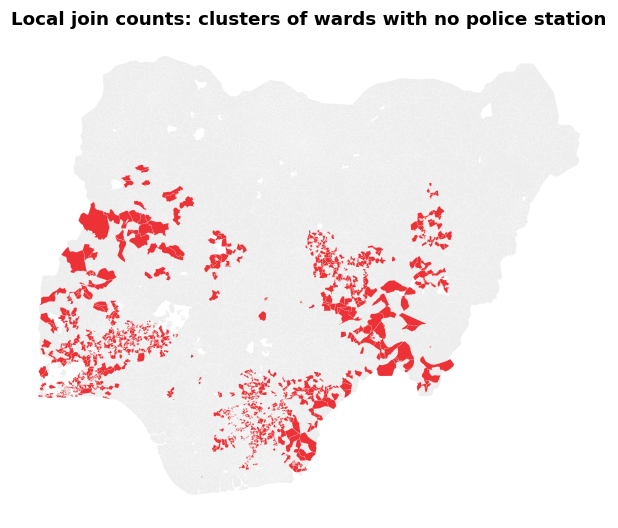

```python
w_binary = libpysal.weights.util.attach_islands(w_queen, w_knn1)
w_binary.transform = "b"
jc = esda.Join_Counts(wards.no_police.values, w_binary, permutations=999)
print(f"BB joins (no-police next to no-police): observed {jc.bb:,.0f}, expected under randomness {jc.mean_bb:,.0f}")
print(f"pseudo p = {jc.p_sim_bb:.3f}")

ljc = esda.Join_Counts_Local(connectivity=w_binary, permutations=999, seed=42).fit(wards.no_police.values)
wards["dark_zone"] = (wards.no_police == 1) & (ljc.p_sim < 0.05)
print(f"\nSignificant security dark-zone wards: {wards.dark_zone.sum():,}")
print(f"People living in them: {wards.loc[wards.dark_zone, 'pop_2025_sum'].sum()/1e6:.1f} million")
print(wards[wards.dark_zone].statename.value_counts().head(6).to_string())

fig, ax = plt.subplots(figsize=(7, 6))
wards.set_geometry("geometry_plot").plot(color="#eeeeee", ax=ax, linewidth=0.2, edgecolor=EDGE)
wards[wards.dark_zone].set_geometry("geometry_plot").plot(color=DSN_RED, ax=ax, linewidth=0.2, edgecolor=EDGE)
base_map(ax, "Local join counts: clusters of wards with no police station")
plt.show()
```

**Interpretation.**

- **Global Join Counts**: observed 22,557 no-police/no-police neighbour pairs vs 22,542 expected, pseudo **$p = 0.38$**. We **cannot reject $H_0$**. With 93% of wards uncovered, two uncovered wards sitting side by side is exactly what chance produces. This is an important lesson: **not every variable is spatially clustered, and the test protects us from seeing patterns that are not there.**
- **Local join counts** still flag **1,356 wards** (about **34.7 million people**) where a ward *and all of its neighbours* have no station, more than chance allows for those specific neighbourhoods. They are most common in **Osun, Plateau, Lagos, Oyo, Abia and Enugu**.

**Decision.** The national picture is "uniformly thin coverage", not "clustered gaps". The local dark zones are a shortlist for new stations. As with clinics, Lagos appearing here suggests registry gaps to verify.

## Use Case 10: One slope or many? (GWR)

**The problem.** A national education policy assumes that as purchasing power rises, school provision per child rises by the same amount everywhere. Is one national rule fair?

**Hypothesis.**

- $H_0$: the relationship between purchasing power and schools per 10,000 people is the same everywhere (stationary).
- $H_1$: the relationship changes across the country (spatial heterogeneity).

To keep the computation fast we work at **LGA level** (wards aggregated into their Local Government Areas).

**The usual approach.** One national OLS slope.

```python
lga = wards.dissolve(by=["statename", "lganame"], aggfunc={"pop_2025_sum": "sum", "schools_count": "sum",
                                                           "purchasing_power": "mean"}).reset_index()
lga = lga[lga.pop_2025_sum > 0].reset_index(drop=True)
lga["schools_per_10k"] = lga.schools_count / lga.pop_2025_sum * 1e4
lga["log_density"] = np.log(lga.pop_2025_sum / (lga.to_crs(3857).area / 1e6))

y10 = lga.schools_per_10k.values.reshape(-1, 1)
X10 = lga[["purchasing_power", "log_density"]].values
ols10 = spreg.OLS(y10, X10, name_y="schools_per_10k", name_x=["purchasing_power", "log_density"])
print(f"LGAs: {len(lga)}")
print(f"National slope for purchasing power: {ols10.betas[1][0]:.2f} (p = {ols10.t_stat[1][1]:.4f})")
print(f"R^2 = {ols10.r2:.3f}")
```

```
LGAs: 774
National slope for purchasing power: 2.72 (p = 0.0000)
R^2 = 0.134
```

**What the usual approach tells us.** Across **774 LGAs**, one national slope says each unit of purchasing power adds about **2.72 schools per 10,000 people** ($p < 0.001$). But the model explains only **13.4%** of the variation, so one line fits the country poorly.

**The spatial statistics approach.** **Geographically Weighted Regression** fits a separate regression around every LGA, weighting nearby LGAs more (adaptive bisquare kernel, bandwidth chosen by AICc). The result is a *map of slopes*. We compare its fit to the global model and map where the local slope is significant.

```
Optimal bandwidth: 48 nearest LGAs
AICc  global OLS = 2091.4  |  GWR = 1830.2
R^2   global OLS = 0.134  |  GWR = 0.571

Local slope for purchasing power ranges from -0.77 to 1.21
Significant positive in 48 LGAs, significant negative in 0
```

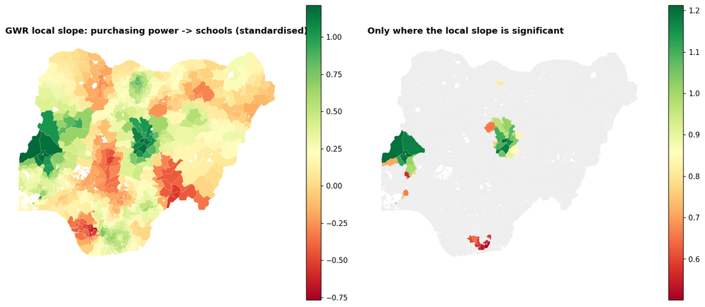

```python
from mgwr.gwr import GWR
from mgwr.sel_bw import Sel_BW

coords = np.column_stack([lga.centroid.x, lga.centroid.y])
Xs = (X10 - X10.mean(0)) / X10.std(0)
ys = (y10 - y10.mean()) / y10.std()
bw = Sel_BW(coords, ys, Xs, kernel="bisquare", fixed=False).search(criterion="AICc")
gwr10 = GWR(coords, ys, Xs, bw, kernel="bisquare", fixed=False).fit()
ols_std = spreg.OLS(ys, Xs)
print(f"Optimal bandwidth: {bw:.0f} nearest LGAs")
print(f"AICc  global OLS = {ols_std.aic:.1f}  |  GWR = {gwr10.aicc:.1f}")
print(f"R^2   global OLS = {ols_std.r2:.3f}  |  GWR = {gwr10.R2:.3f}")

lga["gwr_slope_pp"] = gwr10.params[:, 1]
filtered = gwr10.filter_tvals()[:, 1]
lga["gwr_slope_sig"] = np.where(filtered != 0, lga.gwr_slope_pp, np.nan)
print(f"\nLocal slope for purchasing power ranges from {lga.gwr_slope_pp.min():.2f} to {lga.gwr_slope_pp.max():.2f}")
print(f"Significant positive in {(lga.gwr_slope_sig > 0).sum()} LGAs, significant negative in {(lga.gwr_slope_sig < 0).sum()}")

fig, axes = plt.subplots(1, 2, figsize=(14, 6))
lga.plot(column="gwr_slope_pp", cmap="RdYlGn", legend=True, ax=axes[0], linewidth=0.2, edgecolor=EDGE)
base_map(axes[0], "GWR local slope: purchasing power -> schools (standardised)")
lga.plot(color="#eeeeee", ax=axes[1], linewidth=0.2, edgecolor=EDGE)
lga.dropna(subset=["gwr_slope_sig"]).plot(column="gwr_slope_sig", cmap="RdYlGn", legend=True, ax=axes[1], linewidth=0.2, edgecolor=EDGE)
base_map(axes[1], "Only where the local slope is significant")
plt.tight_layout(); plt.show()
lga[["statename", "lganame", "gwr_slope_pp", "gwr_slope_sig"]].to_parquet("../data/processed/lga_gwr_results.parquet")
```

**Interpretation.**

- The optimal **bandwidth is 48 nearest LGAs**: each local regression borrows information from its 48 closest LGAs.
- **GWR fits far better**: $R^2$ rises from **0.134 to 0.571** and AICc drops from **2091 to 1830** (a drop of more than 3 is meaningful). We **reject $H_0$**: the relationship is not the same everywhere.
- The local (standardised) slope ranges from **$-0.77$ to $1.21$**, but after correcting for multiple testing it is **significantly positive in only 48 LGAs** and significantly negative in none. In most of the country, purchasing power adds little once local context is allowed for.

**Decision.** A single national rule ("more wealth, more schools") holds in a minority of LGAs. Education planning should use the local-slope map: where the slope is significant, school supply is tracking wealth, which risks leaving poorer LGAs behind.

## Use Case 11: Malaria and poverty

**The problem.** A malaria programme has bed nets and seasonal chemoprevention for a limited number of areas. Where is prevalence highest, and does poverty explain it?

The data is the **Malaria Atlas Project** *Plasmodium falciparum* parasite rate in children aged 2–10 (PfPR$_{2-10}$) for 2025, averaged within each ward.

**Hypothesis.**

- $H_0$: malaria prevalence is spread randomly and is unrelated to purchasing power.
- $H_1$: prevalence clusters geographically, and poorer wards carry more malaria.

**The usual approach.** Rank wards by prevalence and fit an OLS of prevalence on purchasing power, urban status and population density.

```python
has_mal = wards.malaria_pfpr_2025_pct.notna()
mal = wards[has_mal].reset_index(drop=True)
print(f"Wards with a malaria estimate: {len(mal):,}")
print(mal.malaria_pfpr_2025_pct.describe().round(1).to_string())
print("\nHighest-prevalence states (ward average, %):")
print(mal.groupby("statename").malaria_pfpr_2025_pct.mean().sort_values(ascending=False).head(5).round(1).to_string())

y11 = mal.malaria_pfpr_2025_pct.values.reshape(-1, 1)
X11 = np.column_stack([mal.purchasing_power, (mal.urban == "Yes").astype(float),
                       np.log(mal.pop_2025_sum / mal.ward_area_sqkm)])
names11 = ["purchasing_power", "urban", "log_density"]
w11 = libpysal.weights.util.attach_islands(
    libpysal.weights.Queen.from_dataframe(mal, use_index=False, silence_warnings=True),
    libpysal.weights.KNN.from_dataframe(mal.set_geometry(mal.centroid), k=1))
w11.transform = "r"
ols11 = spreg.OLS(y11, X11, w=w11, spat_diag=True, moran=True, name_y="pfpr_pct", name_x=names11)
print()
print(pd.DataFrame({"coef": ols11.betas.ravel(), "p": [t[1] for t in ols11.t_stat]},
                   index=["constant"] + names11).round(4).to_string())
print(f"\nR^2 = {ols11.r2:.3f}")
```

```
Wards with a malaria estimate: 8,874
count    8874.0
mean       25.0
std         6.4
min         6.8
25%        20.9
50%        24.9
75%        29.5
max        43.7

Highest-prevalence states (ward average, %):
statename
Akwa Ibom    33.3
Abia         32.3
Imo          32.3
Ekiti        30.5
Ondo         30.3
```

```
                     coef       p
constant          29.7132  0.0000
purchasing_power  -0.3207  0.0306
urban             -3.3276  0.0000
log_density       -0.6972  0.0000

R^2 = 0.130
```

**What the usual approach tells us.** Ward prevalence averages **25%** (from 6.8% to 43.7%). The highest state averages are in the south-east: **Akwa Ibom (33.3%), Abia and Imo (32.3%)**.

The OLS says poorer wards carry slightly more malaria (purchasing power coefficient **$-0.32$, $p = 0.03$**), and urban and denser wards carry less (urban **$-3.3$** percentage points). But $R^2 = 0.13$: these factors explain little, and the model assumes every ward is independent.

**The spatial statistics approach.** Map where prevalence clusters with **Moran's $I$ and LISA**, then check the OLS residuals with the **LM tests** and refit with the spatial model they point to. Note that the MAP surface is about 5 km per pixel, so small neighbouring wards can share pixels; this smooths the map and makes some autocorrelation expected.

```
Moran's I (malaria prevalence) = 0.933, pseudo p = 0.001
```

```
High-High malaria hot-spot wards: 2,175 with 48.4 million people
statename
Akwa Ibom    297
Imo          244
Abia         191
Niger        138
Ondo         125
Kaduna       111

Residual Moran's I = 0.919 | Robust LM-lag = 184.2 | Robust LM-error = 783.9
GM_Error_Het
                  OLS coef  SEM coef  OLS std err  SEM std err
constant            29.713    26.069        0.250        0.820
purchasing_power    -0.321     0.007        0.148        0.031
urban               -3.328    -1.118        0.238        0.080
log_density         -0.697    -0.213        0.042        0.012
lambda = 0.984
```

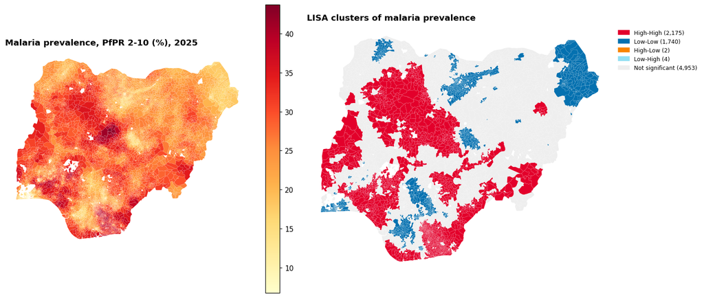

```python
moran_mal = esda.Moran(mal.malaria_pfpr_2025_pct.values, w11, permutations=999)
print(f"Moran's I (malaria prevalence) = {moran_mal.I:.3f}, pseudo p = {moran_mal.p_sim:.3f}")
lisa_mal = esda.Moran_Local(mal.malaria_pfpr_2025_pct.values, w11, permutations=999, seed=42)
hh = (lisa_mal.q == 1) & (lisa_mal.p_sim < 0.05)
print(f"High-High malaria hot-spot wards: {hh.sum():,} with {mal.pop_2025_sum[hh].sum()/1e6:.1f} million people")
print(mal[hh].statename.value_counts().head(6).to_string())

print(f"\nResidual Moran's I = {ols11.moran_res[0]:.3f} | Robust LM-lag = {ols11.rlm_lag[0]:.1f} | "
      f"Robust LM-error = {ols11.rlm_error[0]:.1f}")
sem11 = spreg.GM_Error_Het(y11, X11, w=w11, name_y="pfpr_pct", name_x=names11)
print(pd.DataFrame({"OLS coef": ols11.betas.ravel()[:4], "SEM coef": sem11.betas.ravel()[:4],
                    "OLS std err": ols11.std_err[:4], "SEM std err": sem11.std_err[:4]},
                   index=["constant"] + names11).round(3).to_string())
print(f"lambda = {sem11.betas.ravel()[-1]:.3f}")

fig, axes = plt.subplots(1, 2, figsize=(14, 6))
mal.set_geometry("geometry_plot").plot(column="malaria_pfpr_2025_pct", cmap="YlOrRd", legend=True,
                                       ax=axes[0], linewidth=0.2, edgecolor=EDGE)
base_map(axes[0], "Malaria prevalence, PfPR 2-10 (%), 2025")
cls = np.where(lisa_mal.p_sim < 0.05, lisa_mal.q, 0)
mal.set_geometry("geometry_plot").plot(color=[LISA_COLOURS[c] for c in cls], ax=axes[1],
                                       linewidth=0.2, edgecolor=EDGE)
counts = pd.Series(cls).value_counts()
axes[1].legend(handles=[mpatches.Patch(color=LISA_COLOURS[k], label=f"{LISA_LABELS[k]} ({counts.get(k, 0):,})")
                        for k in (1, 3, 4, 2, 0)],
               loc="upper left", bbox_to_anchor=(1.0, 1.0), fontsize=8, frameon=False)
base_map(axes[1], "LISA clusters of malaria prevalence")
plt.tight_layout(); plt.show()
```

**Interpretation.**

- **Moran's $I = 0.933$**: malaria is extremely clustered. Part of this is real (climate, rainfall and ecology change slowly across space) and part comes from the ~5 km MAP surface being shared by small neighbouring wards.
- **LISA finds 2,175 High-High hot-spot wards with about 48.4 million people**, led by **Akwa Ibom, Imo and Abia**, with further clusters in **Niger, Ondo and Kaduna**. These are the contiguous areas where a campaign reaches the most high-burden wards per deployment.
- **The OLS residuals are just as clustered (0.919)**, and Robust LM-error (784) dominates Robust LM-lag (184), so we fit a **Spatial Error Model**.
- In the SEM, **the purchasing power effect disappears (from $-0.32$ to $0.007$)**, and the urban and density effects shrink by about two-thirds. $\lambda = 0.984$: almost all of what OLS attributed to poverty is shared regional geography.

**Decision.** Do not target malaria campaigns by poverty ranking: once geography is accounted for, poverty adds almost nothing. Target the LISA hot-spot clusters directly, and treat urban status as a modest secondary factor.